# Miniproject_2

### Web Scraping to find the corresponding URL of the Official Trailer on Youtube

Using a simple program, we can use the movie title from rotten tomatoes, attach an **"Official Trailer"** string to the title, and attach this to the search query link of website which is https://www.youtube.com/results?search_query= . Forming this URL, we can now use a request get function to gets it html code. This html code actually have the list of the top most official trailer for the corresponding movie title. We can get the top most offical trailer and get its youtube id which will be used for the youtube api.

Upon having the youtube id, we can use the youtube api to query the needed informations. For this youtube api, we only use the **https://www.googleapis.com/youtube/v3/videos** since youtube api has a limited quota. Using the youtube id collected, we can use it to get the statistics and content details. From this statistics we can get the likes, dislikes and etc.

The informations collected will be appended to a list which will be then transferred to a database file. The program below shows this.

*Figure 7. Shows a Sample Youtube Search Page VS its HTML Code*

[figure not shown]

*Figure 8. Shows a Sample Youtube Video Page VS its Youtube APi Counterpart*

[figure not shown]

**Take Note** The program has a Try and Except Scheme since some of the youtube movie trailers have no data on some informations.

**NOTE** Running the code will at least take **3 hours** to finish since a time sleep program was added to safe web scraping. Also, proxy vpn are used also in case of any untoward events.

```python
api_key=''
```

```python
ytdb = sqlite3.connect('yt.db')

ytdb.execute("""CREATE TABLE IF NOT EXISTS yttable (
        Movie Text,
        Youtube_ID Text,
        View_Count Text,
        Like_Count Text,
        Dislike_Count Text,
        Comment_Count Text,
        Duration_Trailer Text,
        Video_Definition Text)""")

ytdb.commit()

list4 = []
xx = 0
xx1 = 0

ytdb = sqlite3.connect('yt.db')
for title1 in title_names:
    vv2 = None
    while vv2 == None:
        avv = None
        title2 = ''
        title2 = title1.replace(' ', '+')+'+Official+Trailer'
        a1 = 'https://www.youtube.com/results?search_query='+title2

        vv = requests.get(a1, proxies=proxies).text

        vv1 = bs4.BeautifulSoup(vv, "html5lib")

        vv2 = vv1.find(rel="spf-prefetch")

        try:
            avv = vv2['href']
        except:
            pass
        time.sleep(2)
        if avv != None:
            xx = xx+1
            xx1 = xx1+1
            print(xx)
            if xx1 == 10:
                time.sleep(10)
                xx1 = 0
            yt_endpoint2 = 'https://www.googleapis.com/youtube/v3/videos'
            yt_details = requests.get(
                yt_endpoint2,
                params=dict(
                    part='contentDetails,statistics',
                    id=avv.replace('/watch?v=', ''),
                    key=api_key
                ), proxies=proxies
            ).json()
            list3 = []
            list3.append(title1)
            list3.append(avv.replace('/watch?v=', ''))
            try:
                list3.append(yt_details['items'][0]['statistics']['viewCount'])
            except:
                print(list3)
                list3.append('')
            try:
                list3.append(yt_details['items'][0]['statistics']['likeCount'])
            except:
                print(list3)
                list3.append('')
            try:
                list3.append(yt_details['items'][0]
                             ['statistics']['dislikeCount'])
            except:
                print(list3)
                list3.append('')
            try:
                list3.append(yt_details['items'][0]
                             ['statistics']['commentCount'])
            except:
                print(list3)
                list3.append('')
            try:
                list3.append(yt_details['items'][0]
                             ['contentDetails']['duration'])
            except:
                print(list3)
                list3.append('')
            try:
                list3.append(yt_details['items'][0]
                             ['contentDetails']['definition'])
            except:
                print(list3)
                list3.append('')
            with ytdb:
                ytdb.execute(
                    "INSERT INTO yttable VALUES (?, ?, ?, ?, ?, ?, ?,?)", list3)
```

### We now have the needed Data! Let's go Describe and Clean it!

DATA DESCRIPTION

Overall the Research Paper was able to generate 3 Database Files which corresponds to each Website, namely: Rotten Tomatoes Database, IMDB Database, YouTube Database, Each of this Database has 1100 Rows of Data representing the Top 100 Movies of each year from 2020 to 2010 (Based on Rotten Tomatoes). Each of the Database has different numbers of Columns. The succeeding table/cells will describe the Data Contents of each Database:

**Rotten Tomatoes Database**

| Column Name | Description |
| --- | --- |
| Year | Year when it was considered at the Top 100 |
| Position | Position in the Top 100 |
| Title | Name of the Movie |
| Tomatometer Score | Percentage of positive Critic reviews |
| Total Count | Number of Total Count of Verified Critic Review |
| Audience Score | Percentage of registered users who have rated the film positively on a 5-star scale |
| Verified Ratings | Number of Verified Audience Ratings |
| Rating | Movie Viewer Rating allowed |
| Genre | Specific Genre of the Movie |
| Directed by | Name of the Director of the Movie |
| Written by | Name of Writer for the Movie |
| In_Theaters | Date of Showing in Movie Theaters |
| On Disc Streaming | Date of Showing on Disc |
| Box Office | Amount of the Movie achieved when in Box Office |
| Run Time | Total Length of the Movie |
| Studio | Name of Studio who created the Film/Movie |

```python
conn1 = sqlite3.connect('sample.db')
df_rt = pd.read_sql(""" SELECT * from mytable""", conn1)
df_rt.head()
```

|  | Year | Position | Title | Tomatometer_Score | Total_Count | Audience_Score | Verfied_Ratings | Rating | Genre | Directed_by | Written_by | In_Theaters | On_Disc_Streaming | Box_Office | Runtime | Studio |
| --- | --- | --- | --- | --- | --- | --- | --- | --- | --- | --- | --- | --- | --- | --- | --- | --- |
| 0 | 2020 | 1 | Portrait of a Lady on Fire (Portrait de la jeu... | 98% | 285 | 92% | 463 | R (for some nudity and sexuality) | Drama | Céline Sciamma | Céline Sciamma | Feb 14, 2020 wide | Mar 27, 2020 |  | 119 minutes | NEON |
| 1 | 2020 | 2 | 1917 (2020) | 89% | 426 | 88% | 30,467 | R (for violence, some disturbing images, and l... | Drama | Sam Mendes | Sam Mendes, Krysty Wilson-Cairns | Jan 10, 2020 wide | Mar 10, 2020 |  | 110 minutes | Universal Pictures |
| 2 | 2020 | 3 | The Invisible Man (2020) | 91% | 360 | 88% | 11,880 | R (for some strong bloody violence, and language) | Horror, Mystery & Suspense, Science Fiction & ... | Leigh Whannell | Leigh Whannell | Feb 28, 2020 wide | Mar 20, 2020 |  | 110 minutes | Universal Pictures |
| 3 | 2020 | 4 | Never Rarely Sometimes Always (2020) | 99% | 177 | 68% | 133 | NR | Drama | Eliza Hittman | Eliza Hittman | Mar 13, 2020 limited | Apr 3, 2020 |  | 95 minutes | Focus Features |
| 4 | 2020 | 5 | Onward (2020) | 88% | 311 | 95% | 8,597 | PG (for action/peril and some mild thematic el... | Action & Adventure, Animation, Kids & Family, ... | Dan Scanlon | Keith Bunin, Jason Headley, Dan Scanlon | Mar 6, 2020 wide | Mar 20, 2020 |  | 114 minutes | Disney/Pixar |

#### IMDB Database

[output not shown]

```python
conn2 = sqlite3.connect('imdb_dataset.db')
df_imdb = pd.read_sql("""SELECT * from imdb""", conn2).replace('N/A', 0)
df_imdb.head()
```

|  | index | Title | imdb ID | Rated | Released | Awards | imdbRating | imdbVotes | MetaCritic | Country | Plot | Genre | Budget | Open Weekend USA | Gross USA | WW Gross |
| --- | --- | --- | --- | --- | --- | --- | --- | --- | --- | --- | --- | --- | --- | --- | --- | --- |
| 0 | 0 | Portrait of a Lady on Fire | tt8613070 | R | 14 Feb 2020 | Nominated for 1 Golden Globe. Another 43 wins ... | 8.1 | 38,202 | 95 | France | On an isolated island in Brittany at the end o... | Drama, Romance | None | $67,344, | $3,759,854 | $9,912,433 |
| 1 | 1 | 1917 | tt8579674 | R | 10 Jan 2020 | Won 3 Oscars. Another 110 wins & 161 nominations. | 8.3 | 327,805 | 78 | USA, UK, India, Spain, Canada | April 6th, 1917. As a regiment assembles to wa... | Drama, War | $95,000,000 | $576,216, | $159,227,644 | $374,717,445 |
| 2 | 2 | The Invisible Man | tt1051906 | R | 28 Feb 2020 | 4 nominations. | 7.1 | 98,734 | 72 | Australia, USA, Canada | When Cecilia's abusive ex takes his own life a... | Horror, Mystery, Sci-Fi, Thriller | $7,000,000 | $28,205,665, | $64,914,050 | $124,515,298 |
| 3 | 3 | Never Rarely Sometimes Always | tt7772582 | PG-13 | 03 Apr 2020 | 3 wins & 2 nominations. | 7.2 | 3,078 | 91 | UK, USA | A pair of teenage girls in rural Pennsylvania ... | Drama | None | $16,285, | $16,565 | $16,565 |
| 4 | 4 | Onward | tt7146812 | PG | 06 Mar 2020 | 1 win. | 7.5 | 58,492 | 61 | USA | Two elven brothers embark on a quest to bring ... | Animation, Adventure, Comedy, Family, Fantasy | None | $39,119,861, | $61,555,145 | $103,181,419 |

**Youtube Database**

| Column Name | Description |
| --- | --- |
| Movie Title | Movie Title Corresponding to the Rotten Tomatoes Database |
| Youtube ID | ID of the Trailer |
| View Count | Number of Views of the Trailer |
| Like Count | Number of Likes |
| Dislike Count | Number of Dislikes |
| Comment Count | Number of Comments the Trailer have |
| Duration Trailer | Length of Trailer |
| Video Definition | Type of Video kind of the Trailer |

```python
conn3 = sqlite3.connect('yt.db')
df_yt = pd.read_sql(""" SELECT * from yttable""", conn3)
df_yt.head()
```

|  | Movie | Youtube_ID | View_Count | Like_Count | Dislike_Count | Comment_Count | Duration_Trailer | Video_Definition |
| --- | --- | --- | --- | --- | --- | --- | --- | --- |
| 0 | Portrait of a Lady on Fire (Portrait de la jeu... | R-fQPTwma9o | 2456884 | 14441 | 384 | 813 | PT2M16S | hd |
| 1 | 1917 (2020) | gZjQROMAh_s | 14853543 | 89564 | 2287 | 8546 | PT2M26S | hd |
| 2 | The Invisible Man (2020) | Pso0Aj_cTh0 | 3463541 | 25608 | 1389 | 2651 | PT2M42S | hd |
| 3 | Never Rarely Sometimes Always (2020) | 3ReGp_OUGPM | 166180 | 2407 | 122 | 347 | PT2M9S | hd |
| 4 | Onward (2020) | gn5QmllRCn4 | 11748928 | 123983 | 8087 | 0 | PT2M29S | hd |

**NOTE:** All stored data in the database are in string data type, due to this, we need further data processing of the data.

DATA PREPROCESSING

Data extracted will be cleaned prior analysis. First of, as observed there are cells with null values. These rows won't be dropped since there are other important data on those rows.

### Rotten Tomatoes Dataframe processing

For Faster Processing,let's pull all of these integer type columns to one specific dataframe. Some needed processing of specific columns are as follows:

```
1. Tomatometer_Score = Take out the Percentage Sign
2. Audience_Score = Take out the Percentage Sign
3. Runtime = Take out the minute word
4. Box_Office = Take out the Dollar Sign
5. Duration Trailer = Show in Minutes
```

Year, Tomatometer Score, Total Count,Audience Score, Verified_Ratings, Box_Office, Runtime are converted to a numeric data type. Movie titles are converted to lower case and the movie year appending to the movie is removed.

```python
import pandas as pd
pd.options.mode.chained_assignment = None
df_rt = df_rt[['Year', 'Position', 'Title', 'Tomatometer_Score', 'Total_Count',
               'Audience_Score', 'Verfied_Ratings', 'Box_Office', 'Runtime']]
df_rt['Year'] = pd.to_numeric(df_rt['Year'])
df_rt['Position'] = pd.to_numeric(df_rt['Position'])
df_rt['Tomatometer_Score'] = pd.to_numeric(
    df_rt['Tomatometer_Score'].str.replace('%', ""))
df_rt['Total_Count'] = pd.to_numeric(df_rt['Total_Count'].str.replace(',', ''))
df_rt['Audience_Score'] = pd.to_numeric(
    df_rt['Audience_Score'].str.replace('%', ""), errors='coerce')
df_rt['Verfied_Ratings'] = pd.to_numeric(
    df_rt['Verfied_Ratings'].str.replace(',', ''), errors='coerce')
df_rt['Box_Office'] = df_rt['Box_Office'].str.replace(',', '').replace('$', '')
df_rt['Box_Office'] = pd.to_numeric(df_rt['Box_Office'].str.replace('$', ''))
df_rt['Runtime'] = pd.to_numeric(df_rt['Runtime'].str.replace('minutes', ''))
df_rt['Title'] = df_rt.Title.str.lower().str.extract('(.+) \(\d{4}\)?')
df_rt = df_rt.set_index('Title', drop=True)

rot_index = [(re.sub(r'\([^()]*\)', '', index)).lower().strip()
             for index in df_rt.index]
df_rt.index = rot_index

df_rt.head()
```

|  | Year | Position | Tomatometer_Score | Total_Count | Audience_Score | Verfied_Ratings | Box_Office | Runtime |
| --- | --- | --- | --- | --- | --- | --- | --- | --- |
| portrait of a lady on fire | 2020 | 1 | 98.0 | 285.0 | 92.0 | 463.0 | NaN | 119.0 |
| 1917 | 2020 | 2 | 89.0 | 426.0 | 88.0 | 30467.0 | NaN | 110.0 |
| the invisible man | 2020 | 3 | 91.0 | 360.0 | 88.0 | 11880.0 | NaN | 110.0 |
| never rarely sometimes always | 2020 | 4 | 99.0 | 177.0 | 68.0 | 133.0 | NaN | 95.0 |
| onward | 2020 | 5 | 88.0 | 311.0 | 95.0 | 8597.0 | NaN | 114.0 |

### IMDB Dataframe processing

Numeric variables such as imdb ratings, votes, budget, gross sales, opening weekend sales are converted to a numeric data type. Awards column, which initially combines all awards and nominations into a single string was split and a column for major and minor awards won and nominations was created. Movie titles are converted to lower case and the movie year appending to the movie is removed.

```python
df_imdb['Major_Awards_Win'] = df_imdb.Awards.str.extract('[wW]on (\d+)')
df_imdb['Major_Awards_Nom'] = df_imdb.Awards.str.extract('for (\d+)')
df_imdb['Minor_Awards_Win'] = df_imdb.Awards.str.extract('(\d+) win')
df_imdb['Minor_Awards_Nom'] = df_imdb.Awards.str.extract('(\d+) nom')

cols = ['Major_Awards_Win', 'Major_Awards_Nom',
        'Minor_Awards_Win', 'Minor_Awards_Nom']
df_imdb[cols] = df_imdb[cols].apply(pd.to_numeric).fillna(0)

df_imdb = df_imdb.drop(columns=['index', 'Awards', 'Genre', 'imdb ID', 'Rated',
                                'Released', 'Country', 'Plot'])

for i in ['Budget', 'Open Weekend USA', 'Gross USA', 'WW Gross']:
    df_imdb[i] = df_imdb[i].str[1:].str.replace(
        r',', '').apply(pd.to_numeric, errors='coerce')

df_imdb.imdbVotes = df_imdb.imdbVotes.str.replace(',', '').apply(pd.to_numeric)
df_imdb[['imdbRating', 'imdbVotes']] = df_imdb[[
    'imdbRating', 'imdbVotes']].apply(pd.to_numeric)

df_imdb.sort_values(by='WW Gross').drop_duplicates(subset='Title').sort_index()

df_imdb.Title = df_imdb.Title.str.lower()
df_imdb = df_imdb.set_index('Title', drop=True)

df_imdb.head()
```

| Title | imdbRating | imdbVotes | MetaCritic | Budget | Open Weekend USA | Gross USA | WW Gross | Major_Awards_Win | Major_Awards_Nom | Minor_Awards_Win | Minor_Awards_Nom |
| --- | --- | --- | --- | --- | --- | --- | --- | --- | --- | --- | --- |
| portrait of a lady on fire | 8.1 | 38202.0 | 95 | NaN | 67344.0 | 3759854.0 | 9912433.0 | 0.0 | 1.0 | 43.0 | 124.0 |
| 1917 | 8.3 | 327805.0 | 78 | 95000000.0 | 576216.0 | 159227644.0 | 374717445.0 | 3.0 | 0.0 | 110.0 | 161.0 |
| the invisible man | 7.1 | 98734.0 | 72 | 7000000.0 | 28205665.0 | 64914050.0 | 124515298.0 | 0.0 | 0.0 | 0.0 | 4.0 |
| never rarely sometimes always | 7.2 | 3078.0 | 91 | NaN | 16285.0 | 16565.0 | 16565.0 | 0.0 | 0.0 | 3.0 | 2.0 |
| onward | 7.5 | 58492.0 | 61 | NaN | 39119861.0 | 61555145.0 | 103181419.0 | 0.0 | 0.0 | 1.0 | 0.0 |

### Youtube DataFframe Processing

Youtube: Column: View_Count, Like_Count, Dislike_Count, Comment_Count are converted to a numeric data type. Duration trailer is formatted as PTXMYS, where X and Y are the number of minutes and seconds, respectively. The X and Y information was extracted and formatted in terms of number of minutes. Movie titles were then converted to lower case, and year appended to it removed.

```python
df_yt = df_yt[['Movie', 'View_Count', 'Like_Count',
               'Dislike_Count', 'Comment_Count', 'Duration_Trailer']]
df_yt['View_Count'] = pd.to_numeric(df_yt['View_Count'])
df_yt['Like_Count'] = pd.to_numeric(df_yt['Like_Count'])
df_yt['Dislike_Count'] = pd.to_numeric(df_yt['Dislike_Count'])
df_yt['Comment_Count'] = pd.to_numeric(df_yt['Comment_Count'])

#Changing the formatting of duration trailer
yt1 = df_yt['Duration_Trailer'].str.extract('PT([0-9])M')
yt1 = yt1.replace(np.nan, 0, regex=True)
yt1 = yt1.astype(int)

yt2 = df_yt['Duration_Trailer'].str.extract('M(.+)S')
yt2 = yt2.replace(np.nan, 0, regex=True)
yt2 = (yt2.astype(int))/60
yt3 = yt1 + yt2

df_yt['Duration_Trailer'] = yt3
df_yt.Movie = df_yt.Movie.str.lower()
df_yt = df_yt.set_index('Movie', drop=True)

yt_index = [(re.sub(r'\([^()]*\)', '', index)).lower().strip()
            for index in df_yt.index]
df_yt.index = yt_index

df_yt.head()
```

|  | View_Count | Like_Count | Dislike_Count | Comment_Count | Duration_Trailer |
| --- | --- | --- | --- | --- | --- |
| portrait of a lady on fire | 2456884 | 14441.0 | 384.0 | 813.0 | 2.266667 |
| 1917 | 14853543 | 89564.0 | 2287.0 | 8546.0 | 2.433333 |
| the invisible man | 3463541 | 25608.0 | 1389.0 | 2651.0 | 2.700000 |
| never rarely sometimes always | 166180 | 2407.0 | 122.0 | 347.0 | 2.150000 |
| onward | 11748928 | 123983.0 | 8087.0 | 0.0 | 2.483333 |

```python
#Merging the preprocessed rotten tomatoes and imdb and youtube dataframe

df_score = df_rt.merge(df_imdb, how='left', left_index=True, right_index=True)
df_score = df_score.merge(df_yt, how='left', left_index=True, right_index=True)
```

```python
df_score.head()
```

|  | Year | Position | Tomatometer_Score | Total_Count | Audience_Score | Verfied_Ratings | Box_Office | Runtime | imdbRating | imdbVotes | ... | WW Gross | Major_Awards_Win | Major_Awards_Nom | Minor_Awards_Win | Minor_Awards_Nom | View_Count | Like_Count | Dislike_Count | Comment_Count | Duration_Trailer |
| --- | --- | --- | --- | --- | --- | --- | --- | --- | --- | --- | --- | --- | --- | --- | --- | --- | --- | --- | --- | --- | --- |
| '71 | 2015 | 33 | 96.0 | 137.0 | 81.0 | 17394.0 | 1286219.0 | 100.0 | 7.2 | 49058.0 | ... | 3062178.0 | 0.0 | 1.0 | 12.0 | 29.0 | 1584420 | 3838.0 | 183.0 | 586.0 | 2.516667 |
| 10 cloverfield lane | 2016 | 27 | 90.0 | 306.0 | 79.0 | 60831.0 | 59481553.0 | 90.0 | 7.2 | 279075.0 | ... | 110216998.0 | 0.0 | 0.0 | 15.0 | 46.0 | 10597344 | 36966.0 | 1392.0 | 6850.0 | 1.733333 |
| 12 o'clock boys | 2014 | 81 | 92.0 | 48.0 | 65.0 | 2459.0 | 44108.0 | 76.0 | 6.4 | 1259.0 | ... | 82614.0 | 0.0 | 0.0 | 4.0 | 6.0 | 362872 | 1297.0 | 94.0 | 99.0 | 2.733333 |
| 12 years a slave | 2013 | 2 | 95.0 | 359.0 | 90.0 | 140234.0 | 50628650.0 | 134.0 | 8.1 | 617390.0 | ... | 187733202.0 | 3.0 | 0.0 | 238.0 | 335.0 | 6550189 | 24256.0 | 834.0 | 4096.0 | 2.500000 |
| 127 hours | 2010 | 11 | 93.0 | 233.0 | 85.0 | 95838.0 | 18329466.0 | 94.0 | 7.6 | 339139.0 | ... | 60738797.0 | 0.0 | 6.0 | 23.0 | 144.0 | 12749303 | 39358.0 | 973.0 | 7712.0 | 2.683333 |

5 rows × 24 columns

For some reason or another, after merging the dataframes, some duplicates are produced. No problem. Let's just drop the duplicates

```python
df_score = df_score.reset_index().drop_duplicates(
    'index').set_index('index', drop=True)
```

INSIGHTS/EDA

To determine if a movie's official trailer and movie's success has some correlation or relationship, Exploratory Data Analysis was performed. It should be noted that in this study, a movie's success is defined in three ways: Movie ratings (from imdb and rotten tomatoes), Movie Earnings (Gross Sales, Profit) and Movie Awards (Major / Minor awards won).

First, we need to narrow down the dataframes to only include relevant columns. Additionally, we have to convert some columns into numerical values to make it easier to perform operations with.

Let's introduce some engineered variables.

- Like_Ratio = Like_Count / (Dislike_Count + 1); +1 to prevent undefined values
- Like:View_Ratio = Like_Count / View_Count)
- Profit = World Wide Gross Sales - Budget

```python
df_score['Like_Ratio'] = df_score.Like_Count / (df_score.Dislike_Count + 1)
df_score['Like:View_Ratio'] = df_score.Like_Count / (df_score.View_Count)
df_score['Profit'] = df_score['WW Gross'] - df_score['Budget']

print('% of movies with recorded Worldwide Gross Sales: ',
      df_score['WW Gross'].dropna().size/df_score.shape[0])
```

```
% of movies with recorded Worldwide Gross Sales:  0.8762511373976342
```

For now, we progress the EDA by looking at the correlations between numerical columns

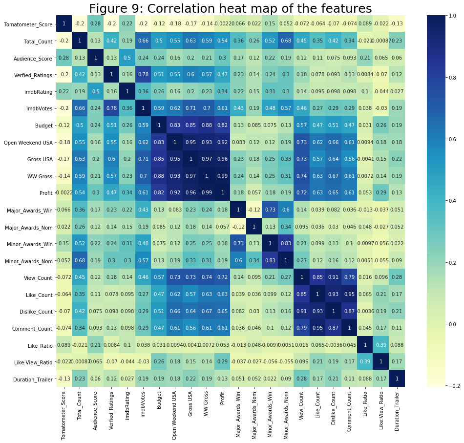

```python
cols_corr = ['Tomatometer_Score', 'Total_Count', 'Audience_Score',
             'Verfied_Ratings', 'imdbRating', 'imdbVotes',
             'Budget', 'Open Weekend USA', 'Gross USA',
             'WW Gross', 'Profit','Major_Awards_Win', 'Major_Awards_Nom',
             'Minor_Awards_Win', 'Minor_Awards_Nom','View_Count',
             'Like_Count', 'Dislike_Count','Comment_Count','Like_Ratio',
             'Like:View_Ratio','Duration_Trailer']

plt.figure(figsize=(16, 14))
sns.heatmap(df_score[cols_corr].corr(), annot=True, cmap="YlGnBu")
plt.title("Figure 9: Correlation heat map of the features", fontsize=25)
plt.show()
```

Since this study is primarily about finding correlation with trailers and movie success.Observations will be limited to youtube statistics and movie success defined above.

These are the observations from figure 9:

**Youtube statistics and movie ratings correlation:**

- Number of views, likes, dislikes, comments has no correlation with rotten tomato ratings.
- Numbers of views has a slight positive correlation with imdb rating.
- The like:dislike and like:view ratio shows little to no correlation with success. Since the number of likes and dislikes scale proportional to views, the number of likes and dislikes themselves are not insightful.
- Number of views, likes, dislikes, comments has a weak correlation with audience score.

**Youtube statistics and movie earnings correlation:**

- Number of views,likes,dislikes,comments, has a strong positive correlation with Gross sales, opening weekend sales, profit.
- The like:dislike shows no correlation while like:view ratio shows a slight correlation.

**Youtube statistics and movie awards correlation:**

- Number of views has a slight positive correlation with major awards win and slightly stronger correlation with Minor awards win and nominations.
- The number of like,dislike,comments and like:dislike and like:view ratio has no correlation with major awards.
- The number of dislikes has a slight positive correlation with respect to minor awards while number of likes does not.

The number views and movie earnings was shown to have the highest correlation among the three indicators of success. Let's plot the variables together to see if any obvious trends can be seen:

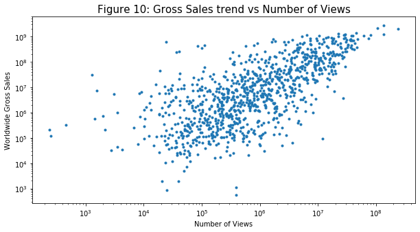

```python
fig = plt.figure(figsize=(10,5))
ax = plt.gca()
plt.plot(df_score['View_Count'],df_score['WW Gross'],'.')
ax.set_xscale('log')
ax.set_yscale('log')
plt.xlabel("Number of Views")
plt.ylabel("Worldwide Gross Sales")
plt.title("Figure 10: Gross Sales trend vs Number of Views", fontsize=15)
plt.show()
```

From figure 10, a linear trend between gross sales number of views can be observed.

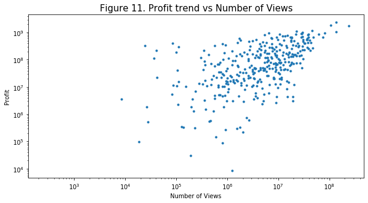

```python
fig = plt.figure(figsize=(10,5))
ax = plt.gca()
plt.plot(df_score['View_Count'],df_score['Profit'],'.')
ax.set_xscale('log')
ax.set_yscale('log')
plt.xlabel("Number of Views")
plt.ylabel("Profit")
plt.title("Figure 11. Profit trend vs Number of Views",fontsize=15)
plt.show()
```

Similar to figure 10, profit vs number of views exhibit a linear trend.

Additionaly, although Like:View ratio doesn't have much correlation with movie profit, there is one trend to spot. Trailers with a LV_ratio gerater than ~0.013 manage to consistently stay above the Profit median, except for one outlier.

In fact, like:dislike ratio can be somewhat indicative of both critic and public score. Plotting the LD_ratio vs Audience Score and Tomatometer_Score, we see that although low like:dislike ratios aren't too indicative of ratings, higher LD_ratios are only found in highly rated movies. Although the trend is a little weak, like:dislike ratio is somewhat of an inbalanced indicator.

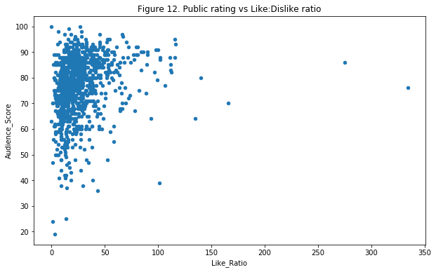

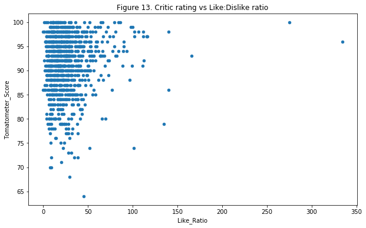

```python
df_score.plot.scatter('Like_Ratio', 'Audience_Score', figsize = (10, 6), title = 'Figure 12. Public rating vs Like:Dislike ratio')
df_score.plot.scatter('Like_Ratio', 'Tomatometer_Score', figsize = (10, 6), title = 'Figure 13. Critic rating vs Like:Dislike ratio')
plt.show()
```

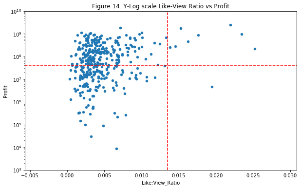

```python
df_score.plot.scatter('Like:View_Ratio', 'Profit', logy = True,
        ylim = (1e3,1e10),
        title = 'Figure 14. Y-Log scale Like-View Ratio vs Profit',
                      figsize = (10, 6))

plt.axhline(df_score.Profit.median(), color = 'red', linestyle = '--')
plt.axvline(0.0135, color = 'red', linestyle = '--')
plt.show()
```

**We've seen how some youtube trailer statistics relate to success. Now let's compare relatively successful movies and unsuccessful movies (based on three criterias such as movie awards, movie ratings and movie earnings) in terms of its movie trailers.**

### Let's investigate the movie trailer characteristics of relatively successful movies and unsuccessful movies.

#### Movie Awards

Movies with majored award of at least 1 are labeled as 1, and those without are labeled 0. The 2 classes are then compared in terms of their median values for the youtube statistics. Median value was used due to presence of outliers.

```python
#Create a column that labels a movie 0 or 1 if it has won a major award
df_score['Major_Awards_Win_Class'] = (df_score['Major_Awards_Win']>0).astype(int)

#Perform basic statistical measures
df_score.groupby('Major_Awards_Win_Class').median()[['View_Count', 'Like_Count',
       'Dislike_Count', 'Comment_Count', 'Duration_Trailer', 'Like_Ratio',
       'Like:View_Ratio']]
```

| Major_Awards_Win_Class | View_Count | Like_Count | Dislike_Count | Comment_Count | Duration_Trailer | Like_Ratio | Like:View_Ratio |
| --- | --- | --- | --- | --- | --- | --- | --- |
| 0 | 521872.0 | 2097.0 | 97.0 | 189.0 | 2.3 | 21.833333 | 0.003856 |
| 1 | 4377111.5 | 15293.5 | 633.5 | 1641.0 | 2.4 | 23.498183 | 0.003753 |

Comparing the median values for movies with and without awards, there is a siginficant difference observed between the number of views for its trailer. Movies with awards have a median view count of 4.38 million compared to 522k views for movies without, which is almost a 4 million view difference. Movies with awards also have more likes, dislikes, comments and is likely augmented by the fact that it has more views. The like-dislike ratio for movies with major awaeds are also higher.23.5 vs 21.83. On average, movies with awards also has trailers which runs 6 seconds longer.

```python
#Create a column that labels a movie 0 or 1 if it has won a minor award
df_score['Minor_Awards_Win_Class'] = (df_score['Minor_Awards_Win']>0).astype(int)

#Perform basic statistical measures
df_score.groupby('Minor_Awards_Win_Class').median()[['View_Count', 'Like_Count',
       'Dislike_Count', 'Comment_Count', 'Duration_Trailer', 'Like_Ratio',
       'Like:View_Ratio']]
```

| Minor_Awards_Win_Class | View_Count | Like_Count | Dislike_Count | Comment_Count | Duration_Trailer | Like_Ratio | Like:View_Ratio |
| --- | --- | --- | --- | --- | --- | --- | --- |
| 0 | 320427.0 | 1170.5 | 64.0 | 115.0 | 2.308333 | 21.792480 | 0.004465 |
| 1 | 734673.0 | 2741.0 | 133.0 | 236.0 | 2.316667 | 21.982507 | 0.003774 |

Similarly, movies with minor awards have higher number of views, likes, dislikes, comments and like:dislike ratio.

#### Movie Ratings (A & B)

Comparing movies with high and low critic ratings in terms of official trailer performance

**A). IMDB Ratings:**

For the purposes of this study and due to data limitations, the threshold for high and low ratings will be based on the 50th percentile of the ratings.

```python
imdb_threshold = pd.Series(df_score['imdbRating']).quantile(0.5)
imdb_threshold
```

```
7.3
```

```python
# Label high rating as 1 and low as 0
df_score['imdbRating_Class'] = (df_score['imdbRating']>imdb_threshold).astype(int)

#Perform basic statistics
df_score.groupby('imdbRating_Class').median()[['View_Count', 'Like_Count',
       'Dislike_Count', 'Comment_Count', 'Duration_Trailer', 'Like_Ratio',
       'Like:View_Ratio']]
```

| imdbRating_Class | View_Count | Like_Count | Dislike_Count | Comment_Count | Duration_Trailer | Like_Ratio | Like:View_Ratio |
| --- | --- | --- | --- | --- | --- | --- | --- |
| 0 | 444892.5 | 1800.0 | 91.0 | 165.0 | 2.283333 | 18.800000 | 0.003515 |
| 1 | 987678.0 | 4699.0 | 155.5 | 365.0 | 2.333333 | 26.726127 | 0.004187 |

Movies with a high imdb rating, on average, has 988k views compared to movies with low rating at 445k. Similarly, like, dislike and comment counts are higher for movies with high rating, which again is likely augmented by the higher view count observed. Like-dislike ratio is also higher.

**B). Rotten Tomatoes Ratings:**

Using similar approach as imdb...

```python
tom_score_threshold = pd.Series(df_score['Tomatometer_Score']).quantile(0.5)
tom_score_threshold
```

```
93.0
```

```python
#Label high rating as 1 and low as 0
df_score['Tomato_Class'] = (df_score['Tomatometer_Score']>tom_score_threshold).astype(int)

#Perform basic statistical measures
df_score.groupby('Tomato_Class').median()[['View_Count', 'Like_Count',
       'Dislike_Count', 'Comment_Count', 'Duration_Trailer', 'Like_Ratio',
       'Like:View_Ratio']]
```

| Tomato_Class | View_Count | Like_Count | Dislike_Count | Comment_Count | Duration_Trailer | Like_Ratio | Like:View_Ratio |
| --- | --- | --- | --- | --- | --- | --- | --- |
| 0 | 1001590 | 3923.5 | 176.5 | 314.5 | 2.383333 | 21.677962 | 0.003689 |
| 1 | 357360 | 1236.0 | 65.0 | 129.0 | 2.266667 | 22.738095 | 0.004035 |

In contrast to the observations from imdb and movie awards, higher rated movies in rotten tomatoes have lower number of views with 350k compared to lower rated movies at 1.00 million views. And could be the reason the number of likes, dislikes and comments are also lower. Higher rated movies, however, have a higher like:dislike ratio. In addition, lower rated movies, on average have trailers thhan run 7.2 seconds longer.

#### Movie Earnings

Let's see how highly profitable movies vs those that do not compare in terms of movie trailer performance. Similar to the treatment of movie ratings, high and low earners will be based on the 50th percentile.

```python
profit_threshold = pd.Series(df_score['Profit']).quantile(0.5)
profit_threshold
```

```
41647656.0
```

```python
#Label high earners as 1 and low earners as 0
df_score['Profit_Class'] = (df_score['Profit']>profit_threshold).astype(int)

#Perform basic statistical measures
df_score.groupby('Profit_Class').median()[['View_Count', 'Like_Count',
       'Dislike_Count', 'Comment_Count', 'Duration_Trailer', 'Like_Ratio',
       'Like:View_Ratio']]
```

| Profit_Class | View_Count | Like_Count | Dislike_Count | Comment_Count | Duration_Trailer | Like_Ratio | Like:View_Ratio |
| --- | --- | --- | --- | --- | --- | --- | --- |
| 0 | 374099.5 | 1340.0 | 74.0 | 137.5 | 2.25 | 20.923077 | 0.003781 |
| 1 | 8892921.0 | 29634.0 | 1359.0 | 2923.5 | 2.50 | 25.328289 | 0.003973 |

The results shown above indicates a very large difference when comparing profitable movies and not. View count differs by an order of magnitude with 8.89 million views compared 374k views for less profitable movies. Like dislike ratio is also higher at 25.33 compared 20.9 for lower profit movies.

RESULTS AND DISCUSSION

Movie success can be difficult to quantify as a single number. Instead, it can be much easier to interpret movie success as a result of three factors: Awards, Ratings and Earnings.

Youtube movie trailer statistics were somewhat related but nowhere near comprehensive indicators of movie success. Each factor of success had varying correlations and indicators from trailers. Let's explore the insights we found for each factor.

#### Ratings Success:

As a preface, it should be mentioned that the number of likes and dislikes are proportional to the number of views, and are not immediately representative of the "likeness" of the trailer. Instead, we look at the *proportion* of like:views and like:dislike to gauge the actual likeness of a trailer.

From the EDA section, it was observed that no correlation was seen between rotten tomatoes score and trailer statistics such as number of views, likes, dislikes and comments. Imdb on the other hand shows a slight positive correlation with the number of views. The lack of correlation in rotten tomatoes can perhaps be due to the more stringent requirements rotten tomatoes have in rating movies. This can be interpreted also to be the independence of critic rating (RT score) of the public reception (Youtube stats).

Also, by segregating the higher rated movies in imdb and rotten tomatoes based on the 50th percentile,it was shown that higher rated movies in IMDB tend to have a higher number of views with a 122% difference between higher / lower rated movies. Like:dislike ratio is also quite higher for higher rated movies with a 42.18% difference. The opposite was observed for rotten tomatoes. Higher rated movies have 181.95% lower number of views. No differece was seen for like:dislike ratio though. Again, this is likely attributed to RT's higher standards and criterieas that goes beyond popularity.

#### Earnings Success

It was observed that profit and the total number of views for trailer had a strong positive linear relationship, with a pearson correlation coefficient 0.72.

There was a slight correlation between like:view ratio and profit and no correlation with like:dislike ratio. This suggests that earnings are more dependent on views rather than likeness. Furthermore, upon closer inspection with a scatter plot, it was shown that movie with a like:view ratio greater than 0.0135 generally managed to earn more than the median, except for one outlier.

#### Awards and Nominations

The difference is slightly pronounced in minor awards, but is significant, nonetheless. Movies with minor awards have a 129% higher number of views. Unlike major awards, movies with or without minor awards have no significant differences in terms of like:dislike ratio (0.8%).

CONCLUSION AND RECOMMENDATION

A list from Rotten Tomatoes' top 100 movies from 2010 to 2020 were referenced to IMDB and Youtube data which were obtained via webscraping and API requests. Results show that trailer view counts can be somewhat indicative of movie success. Movie success was defined as a composition of three factors: Awards, Earnings and Ratings. Each factor had its own correlation and indicators to movie trailer statistics. Comprehensively, though, youtube trailer statistics aren't very powerful indicators of movie success.

This study was limited to the top 100 movies per year from the year 2010 to 2020. It is recommended to increase the scope of the data to have a better understanding of the relationship between movie success and official movie trailers. In addition, these study can be further expanded into a machine learning problem by trying to predict if a movie can be a box office success based on trailer performance.

REFERENCES AND ACKNOWLEDGEMENTS

[1] https://www.ibisworld.com/industry-statistics/market-size/movie-video-production-united-states/

[2] https://en.wikipedia.org/wiki/Rotten_Tomatoes

[3] https://en.wikipedia.org/wiki/IMDb